# WCLA Outreach Analysis - Data Prep

LD

6/18/2020

### Load data

```r
library(data.table)
library(dplyr)
library(sf)
library(stringi)
library(foreign)
library(stringr)

# wd path
root <- "C:/Users/LDaly/Desktop/Census2020/data/"
cb_root <- "C:/Users/LDaly/Desktop/uscb_cartographic_boundaries/"

### load data that doesn't change ####
# load spatial  tract data
tractsp <- st_read(paste0(cb_root, "cb_2018_06_tract_500k/cb_2018_06_tract_500k.shp"), stringsAsFactors = FALSE)
# limit to LA County
tractsp <- tractsp[tractsp$COUNTYFP =="037",]

# group quarters
gq_tract <- fread(paste0(root, "group_quarters_population.csv"), stringsAsFactors =  FALSE, data.table = FALSE,
                  colClasses = c("GEOID"="character", "NAME"="character"))


# read in state dbf of htc data
htc <- read.dbf(paste0(root, "State Census Office/CA_HTC_2020Update.dbf"))
htc$GEOID_1 <- as.character(htc$GEOID_1)

# query only LA Co, keep only columns with tract id and HTC score & top 3 attributes contributing to HTC score
htc <- htc[htc$county_fip=="037", c(3, 17, 41:43)]


regs <- read.dbf(paste0(root, "data_transfer/la_htc_tract_region_2020_intermed.dbf"))
regs <- regs[,c(1, 3, 4, 5)]
regs$geoid <- as.character(regs$geoid)


# load city-tract crosswalk
tract_city_rel <- fread(paste0(root, "Regions_APCA/tract_city_region_crosswalk.csv"),
                        stringsAsFactors =  FALSE, data.table = FALSE,
                        colClasses = c("GEOID"="character", "NAME"="character"))

#### OUTREACH DATA ####
# read in polygon outreach data/
outreach_poly <- fread(paste0(root, "State Census Office/Outreach/download_20200618/Polygon layer_R8_0.csv"),
                  data.table=FALSE, stringsAsFactors = FALSE,fill=TRUE,
                  colClasses = c("tract"="character"))


# read in polygon outreach data/
outreach_pnt <- fread(paste0(root, "State Census Office/Outreach/download_20200618/surveyPoint_R8_0.csv"),
                       data.table=FALSE, stringsAsFactors = FALSE,
                      colClasses = c("x"="numeric", "y"="numeric"))
```

### Clean up outreach data

```r
# clean up polygon outreach data
outreach_poly <- outreach_poly[outreach_poly$tract %like% "6037" | outreach_poly$`Exact Address` %like% "Los Angeles County",
                               c(5, 6, 9:23, 30:32,38:48, 101:105)]

# add leading zero to tract id
outreach_poly$tract <- paste0("0", outreach_poly$tract)

# clean up date field
outreach_poly$start_activity_date <- ifelse( outreach_poly$`Date of Activity / Start Date` %like% " 0:00",
                                             gsub(" 0:00", "", outreach_poly$`Date of Activity / Start Date`),
                                      ifelse( outreach_poly$`Date of Activity / Start Date` %like% " 12:00:00 AM",
                                              gsub(" 12:00:00 AM", "", outreach_poly$`Date of Activity / Start Date`),
                                              outreach_poly$`Date of Activity / Start Date`))

#table(outreach_poly$start_activity_date)

# add total houses reached to the impressions data
# if total # impressions is NA and total # houses is NOT NA, use the total # of houses (this is the only field with data when impressions is NA)
# if total # impressions is NA and total # houses is NA, make the count of impressions 1 (no other number to estimate)
# else use the total number of impressions
outreach_poly$impressions <- ifelse(is.na(outreach_poly$`Total number of impressions`) & !is.na(outreach_poly$`Total number of houses`),
                                    outreach_poly$`Total number of houses`,
                                    ifelse(is.na(outreach_poly$`Total number of impressions`) & is.na(outreach_poly$`Total number of houses`), 1,
                                           outreach_poly$`Total number of impressions`))


# get a month ID in
outreach_poly$month <- stri_match_first_regex(outreach_poly$start_activity_date, "(.*?)\\/")[,2]

# table(outreach_poly$month, useNA = "always") # verify

# make a geographic level field
outreach_poly$level <- ifelse(outreach_poly$`Exact Address` %like% "Los Angeles County", "county", "tract")
table(outreach_poly$level, useNA = "always")
```

```
##
## county  tract   <NA>
##    586  18356      0
```

#### Do extensive activity recoding

```r
# clean up activity type. if activity is other, input other fields
outreach_poly$activity <- ifelse(outreach_poly$`Activity Type` =="activity_type_other" &
                                   (!is.na(outreach_poly$`Other - Activity Type`) & outreach_poly$`Other - Activity Type` != ""),
                                 outreach_poly$`Other - Activity Type`,
                                 outreach_poly$`Activity Type`)

# see the results of the recoding
# table(outreach_poly$activity, useNA = "always")

# if the activity other is the only info --what is the description? can we extract something to summarize from that field?


# More activity recoding:
# when activity type is other, and the other activity type field has no information, pull stuff out of the description field:
outreach_poly$activity <-
  ifelse(outreach_poly$`Activity Type` =="activity_type_other" & outreach_poly$`Other - Activity Type`=="" & (outreach_poly$Description !="" & !outreach_poly$Description %like% "Total adults: "),
         word(outreach_poly$Description, 1, 7),
  ifelse(outreach_poly$`Activity Type` =="activity_type_other" & outreach_poly$`Other - Activity Type`=="" & outreach_poly$Description %like% "Total adults: ",
         "phone banking",
  ifelse(outreach_poly$`Activity Type` =="activity_type_other" & outreach_poly$`Other - Activity Type`=="" & outreach_poly$Description =="", "other",
         outreach_poly$activity)))


# table(outreach_poly$activity, useNA = "always")


# organization -- combine primary organizer wiht parent org (if there is no data for primary organizer)
outreach_poly$organizer <-
  ifelse(outreach_poly$`Primary Organizer`=="", outreach_poly$`Reporting Organization Name`,
         outreach_poly$`Primary Organizer`)


# table(outreach_poly$organizer, useNA = "always")
# head(subset(outreach_poly, organizer ==""))
```

### Clean up outreach point data

```r
### clean up outreach point data
# there is a record from 2019 where the XY fields got scrambled and instead the X value has the report source value. remove
outreach_pnt <- outreach_pnt[outreach_pnt$x !="API", c(3:16, 20, 36:46, 99:103)]

outreach_pnt$x <- as.numeric(outreach_pnt$x)

# clean up date field
outreach_pnt$start_activity_date <- ifelse(outreach_pnt$`Date of Activity / Start Date` %like% " 0:00",
                                           gsub(" 0:00", "", outreach_pnt$`Date of Activity / Start Date`),
                                    ifelse(outreach_pnt$`Date of Activity / Start Date` %like% " 19:00",
                                           gsub(" 19:00", "", outreach_pnt$`Date of Activity / Start Date`),
                                    ifelse(outreach_pnt$`Date of Activity / Start Date` %like% " 7:00",
                                           gsub(" 7:00", "", outreach_pnt$`Date of Activity / Start Date`),
                                    ifelse(outreach_pnt$`Date of Activity / Start Date` %like% "20:00",
                                           gsub(" 20:00", "", outreach_pnt$`Date of Activity / Start Date`),
                                    ifelse(outreach_pnt$`Date of Activity / Start Date` %like% " 12:00:00 AM",
                                           gsub(" 12:00:00 AM", "", outreach_pnt$`Date of Activity / Start Date`),
                                    ifelse(outreach_pnt$`Date of Activity / Start Date` %like% ":00 AM",
                                           gsub(":00 AM", "", outreach_pnt$`Date of Activity / Start Date`),
                                           outreach_pnt$`Date of Activity / Start Date`))))))

# table(outreach_pnt$start_activity_date) # VERIFY

# add total houses reached to the impressions data
# if total # impressions is NA make the count of impressions 1 (no other number to estimate) (no other field has data when impressions is NA)
# else use the total number of impressions
outreach_pnt$impressions <- ifelse(is.na(outreach_pnt$`Total number of impressions`), 1,
                                           outreach_pnt$`Total number of impressions`)
# get a month ID in
outreach_pnt$month <- stri_match_first_regex(outreach_pnt$start_activity_date, "(.*?)\\/")[,2]

# review months
table(outreach_pnt$month, useNA = "always")
```

```
##
##    1   10   11   12    2    3    4    5    6    7    8    9 <NA>
##   83   65   84   84  106   62   91   60   11   13   19   37    0
```

```r
# clean up activity type. if activity is other, input other fields
outreach_pnt$activity <- ifelse(outreach_pnt$`Activity Type` =="activity_type_other" &
                                  (!is.na(outreach_pnt$`Other - Activity Type`) & outreach_pnt$`Other - Activity Type` != ""),
                                 outreach_pnt$`Other - Activity Type`,
                                 outreach_pnt$`Activity Type`)

# verify
# table(outreach_pnt$activity, useNA = "always")

# organization -- combine primary organizer wiht parent org (if there is no data for primary organizer)
outreach_pnt$organizer <-
  ifelse(outreach_pnt$`Primary Organizer`=="", outreach_pnt$`Reporting Organization Name`,
         outreach_pnt$`Primary Organizer`)
```

### Spatial join points to tracts

#### Make the outreach points spatial

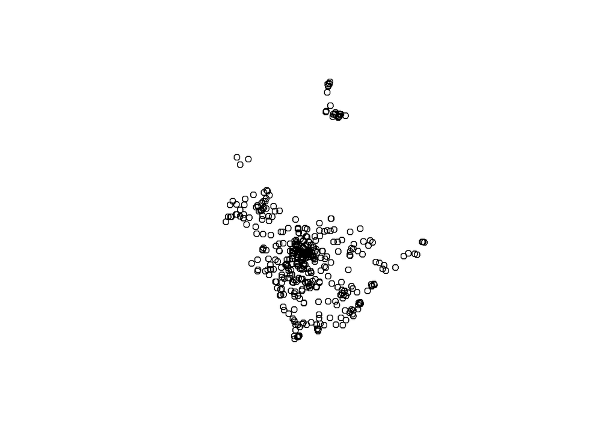

```r
# make xy spatial
outreach_pnt_sp <-  st_as_sf(outreach_pnt, coords = c("x", "y"), crs=4326)


# test plot
plot(outreach_pnt_sp$geometry)
```

#### Join points to tracts to assign outreach activities to tracts

```r
# project tracts and points
tractsp_prj <- st_transform(tractsp, 3310)
pnt_prj <- st_transform(outreach_pnt_sp, 3310)

# spatial join points to tracts
pnt_tract <- st_join(tractsp_prj, pnt_prj)


# Verify tracts have been duplicated where there are multiple points
# review
subset(pnt_tract, GEOID=="06037482503")
```

```
## Simple feature collection with 6 features and 43 fields
## geometry type:  MULTIPOLYGON
## dimension:      XY
## bbox:           xmin: 175426.9 ymin: -438414 xmax: 176276 ymax: -437442.4
## epsg (SRID):    3310
## proj4string:    +proj=aea +lat_1=34 +lat_2=40.5 +lat_0=0 +lon_0=-120 +x_0=0 +y_0=-4000000 +ellps=GRS80 +towgs84=0,0,0,0,0,0,0 +units=m +no_defs
##        STATEFP COUNTYFP TRACTCE             AFFGEOID       GEOID    NAME
## 1037        06      037  482503 1400000US06037482503 06037482503 4825.03
## 1037.1      06      037  482503 1400000US06037482503 06037482503 4825.03
## 1037.2      06      037  482503 1400000US06037482503 06037482503 4825.03
## 1037.3      06      037  482503 1400000US06037482503 06037482503 4825.03
## 1037.4      06      037  482503 1400000US06037482503 06037482503 4825.03
## 1037.5      06      037  482503 1400000US06037482503 06037482503 4825.03
##        LSAD  ALAND AWATER CreationDate                         Creator
## 1037     CT 729678      0              Fradkin_Leonid_cacensus2020_hub
## 1037.1   CT 729678      0              Fradkin_Leonid_cacensus2020_hub
## 1037.2   CT 729678      0              Fradkin_Leonid_cacensus2020_hub
## 1037.3   CT 729678      0              Fradkin_Leonid_cacensus2020_hub
## 1037.4   CT 729678      0              Fradkin_Leonid_cacensus2020_hub
## 1037.5   CT 729678      0              Fradkin_Leonid_cacensus2020_hub
##        EditDate Editor Reporting Organization Name Parent Organization
## 1037                              garveyelementary
## 1037.1                            garveyelementary
## 1037.2                            garveyelementary
## 1037.3                            garveyelementary
## 1037.4                            garveyelementary
## 1037.5                            garveyelementary
##            Activity Type Other - Activity Type
## 1037             meeting
## 1037.1           meeting
## 1037.2           meeting
## 1037.3           meeting
## 1037.4 training_delivery
## 1037.5 training_delivery
##        Date of Activity / Start Date Description Start time End time
## 1037           1/10/2020 12:00:00 AM
## 1037.1         1/17/2020 12:00:00 AM
## 1037.2          2/1/2020 12:00:00 AM
## 1037.3         1/23/2020 12:00:00 AM
## 1037.4         1/23/2020 12:00:00 AM
```

[output cut: 56 more lines]

```
## 1037.5 2730 North Del Mar Avenue, Rosemead, CA 91770 SELF SERVICE PORTAL
##        start_activity_date impressions month          activity
## 1037             1/10/2020          53     1           meeting
## 1037.1           1/17/2020          15     1           meeting
## 1037.2            2/1/2020          21     2           meeting
## 1037.3           1/23/2020          19     1           meeting
## 1037.4           1/23/2020          19     1 training_delivery
## 1037.5           2/11/2020          18     2 training_delivery
##               organizer                       geometry
## 1037   garveyelementary MULTIPOLYGON (((175426.9 -4...
## 1037.1 garveyelementary MULTIPOLYGON (((175426.9 -4...
## 1037.2 garveyelementary MULTIPOLYGON (((175426.9 -4...
## 1037.3 garveyelementary MULTIPOLYGON (((175426.9 -4...
## 1037.4 garveyelementary MULTIPOLYGON (((175426.9 -4...
## 1037.5 garveyelementary MULTIPOLYGON (((175426.9 -4...
```

## Summarize outreach data

### Summarize by Reporting Organization and Tract

#### Summarize Polygons

- keep only 2020 outreach events.
- group by month, reporting organization and tract

```r
# summarize activities by tract by month
out_org_month_sum <-
  outreach_poly %>%

  # keep only recent outreach events (in 2020 only)
  filter(start_activity_date %like% "/2020") %>%

  # group by tract, activity type and activity date
  group_by(level, tract,`Reporting Organization Name`, month) %>%

  # get a count of activities & total number of impressions
  summarize(count = length(tract),
            sum_impressions = sum(impressions, na.rm = T))

head(out_org_month_sum)
```

```
## # A tibble: 6 x 6
## # Groups:   level, tract, Reporting Organization Name [4]
##   level  tract `Reporting Organization Name`    month count sum_impressions
##   <chr>  <chr> <chr>                            <chr> <int>           <dbl>
## 1 county 0     CAIRLA                           4         3            4500
## 2 county 0     California Black Women's Health~ 4         1             228
## 3 county 0     Child Care Resource Center Inc   4         8           22024
## 4 county 0     Child Care Resource Center Inc   5       120         3447733
## 5 county 0     Consejo de Federaciones Mexican~ 3         2           44289
## 6 county 0     Consejo de Federaciones Mexican~ 4        86         9508324
```

```r
# summarize activities by tract by month
out_priorg_month_sum <-
  outreach_poly %>%

  # keep only recent outreach events (in 2020 only)
  filter(start_activity_date %like% "/2020") %>%

  # group by tract, activity type and activity date
  group_by(level, tract, organizer, month) %>%

  # get a count of activities & total number of impressions
  summarize(count = length(tract),
            sum_impressions = sum(impressions, na.rm = T))

head(out_priorg_month_sum)
```

```
## # A tibble: 6 x 6
## # Groups:   level, tract, organizer [2]
##   level  tract organizer                        month count sum_impressions
##   <chr>  <chr> <chr>                            <chr> <int>           <dbl>
## 1 county 0     A New Way of Life Reentry Proje~ 3         1            2825
## 2 county 0     A New Way of Life Reentry Proje~ 4         2            5826
## 3 county 0     A New Way of Life Reentry Proje~ 5         1            1848
## 4 county 0     AltaMed Health Services Corp     3         1          322374
## 5 county 0     AltaMed Health Services Corp     4         2        11126434
## 6 county 0     AltaMed Health Services Corp     5         1            7992
```

#### Summarize Points

- keep only 2020 outreach events.
- group by month, reporting organization and tract

```r
pnt_org_month_sum <-
  pnt_tract %>%
  as.data.frame() %>%   # convert to data frame for simplicity

  # keep only recent outreach events (in 2020 only)
  filter(start_activity_date %like% "/2020") %>%

  # group by tract, activity type and activity date
  group_by(GEOID, `Reporting Organization Name`, month) %>%

  # get a count of activities & total number of impressions
  summarize(count = length(GEOID),
            sum_impressions = sum(impressions, na.rm = T))

head(pnt_org_month_sum)
```

```
## # A tibble: 6 x 5
## # Groups:   GEOID, Reporting Organization Name [6]
##   GEOID    `Reporting Organization Name`        month count sum_impressions
##   <chr>    <chr>                                <chr> <int>           <dbl>
## 1 0603710~ Child Care Resource Center Inc       5         1             100
## 2 0603710~ Consejo de Federaciones Mexicanas e~ 4         1             225
## 3 0603710~ Community Partners fbo Latino Equal~ 2         1              45
## 4 0603710~ LA City                              2         1              30
## 5 0603710~ LA City                              1         1              30
## 6 0603711~ LA City                              2         1              12
```

```r
# primary organizer
pnt_priorg_month_sum <-
  pnt_tract %>%
  as.data.frame() %>%   # convert to data frame for simplicity

  # keep only recent outreach events (in 2020 only)
  filter(start_activity_date %like% "/2020") %>%

  # group by tract, activity type and activity date
  group_by(GEOID, organizer, month) %>%

  # get a count of activities & total number of impressions
  summarize(count = length(GEOID),
            sum_impressions = sum(impressions, na.rm = T))

head(pnt_priorg_month_sum)
```

```
## # A tibble: 6 x 5
## # Groups:   GEOID, organizer [5]
##   GEOID      organizer                          month count sum_impressions
##   <chr>      <chr>                              <chr> <int>           <dbl>
## 1 060371043~ El Nido Family Centers             4         1             225
## 2 060371043~ El Nido Family Centers             5         1             100
## 3 060371046~ NALEO Educational Fund             2         1              45
## 4 060371046~ Pacoima Beautiful                  2         1              30
## 5 060371066~ Secretary of State Alex Padilla's~ 1         1              30
## 6 060371133~ Archdiocese                        2         1              12
```

#### Merge point and polygon outreach data

```r
# bind dataframes long-wise

# counts and impressions of activities by month
org_month_sum <-

  # rbind points to polygons
bind_rows(
pnt_org_month_sum,

  # prepare polygons
out_org_month_sum %>%
  filter(level =="tract") %>%
  rename("GEOID"=tract) %>%
  ungroup %>% select(-level)) %>%

  # summarize by geoid, activity type and month to get total counta nd impressions
  group_by(GEOID, `Reporting Organization Name`,  month) %>%
  summarize(count_act = sum(count, na.rm = T),
            sum_impressions = sum(sum_impressions, na.rm = T))



# counts and impressions of activities by month - PRIMARY ORGANIZER
priorg_month_sum <-

  # rbind points to polygons
bind_rows(
pnt_priorg_month_sum,

  # prepare polygons
out_priorg_month_sum %>%
  filter(level =="tract") %>%
  rename("GEOID"=tract) %>%
  ungroup %>% select(-level)) %>%

  # summarize by geoid, activity type and month to get total counta nd impressions
  group_by(GEOID, organizer,  month) %>%
  summarize(count_act = sum(count, na.rm = T),
            sum_impressions = sum(sum_impressions, na.rm = T))
```

### Summarize by Activity Type and Tract

#### Summarize Polygons

- keep only 2020 outreach events.
- Version 1: group by month, activity type and tract
- Version 2: group by month and tract

```r
# summarize activities by tract by month
out_act_month_sum <-
  outreach_poly %>%

  # keep only recent outreach events (in 2020 only)
  filter(start_activity_date %like% "/2020") %>%

  # group by tract, activity type and activity date
  group_by(level, tract,`Activity Type`, activity, month) %>%

  # get a count of activities & total number of impressions
  summarize(count = length(tract),
            sum_impressions = sum(impressions, na.rm = T))

head(out_act_month_sum)
```

```
## # A tibble: 6 x 7
## # Groups:   level, tract, Activity Type, activity [6]
##   level  tract `Activity Type` activity         month count sum_impressions
##   <chr>  <chr> <chr>           <chr>            <chr> <int>           <dbl>
## 1 county 0     activity_type_~ Award Census In~ 4         2            1925
## 2 county 0     activity_type_~ Community Educa~ 5         1              10
## 3 county 0     activity_type_~ Facebook post    3         4            1742
## 4 county 0     activity_type_~ Launched biling~ 5         1             500
## 5 county 0     activity_type_~ podcast          4         1             900
## 6 county 0     activity_type_~ radio interview  4         1           10000
```

```r
# table(out_act_month_sum$`Activity Type`, out_act_month_sum$month, useNA = "always")
#table(out_act_month_sum$activity)


# summarize outreac by tract by month, regardless of activity type
out_month_sum <-
  outreach_poly %>%

  # keep only recent outreach events (in 2020 only)
  filter(start_activity_date %like% "/2020") %>%

  # group by tract and activity date
  group_by(level, tract, month) %>%

  # get a count of activities & total number of impressions
  summarize(count = length(tract),
            sum_impressions = sum(impressions, na.rm = T))

#table(out_month_sum$month, useNA = "always")
```

#### Summarize Points

- keep only 2020 outreach events.
- Version 1: group by month, activity type and tract
- Version 2: group by month and tract

```r
pnt_act_month_sum <-
  pnt_tract %>%
  as.data.frame() %>%   # convert to data frame for simplicity

  # keep only recent outreach events (in 2020 only)
  filter(start_activity_date %like% "/2020") %>%

  # group by tract, activity type and activity date
  group_by(GEOID, `Activity Type`,activity, month) %>%

  # get a count of activities & total number of impressions
  summarize(count = length(GEOID),
            sum_impressions = sum(impressions, na.rm = T))

head(pnt_act_month_sum)
```

```
## # A tibble: 6 x 6
## # Groups:   GEOID, Activity Type, activity [5]
##   GEOID       `Activity Type`   activity        month count sum_impressions
##   <chr>       <chr>             <chr>           <chr> <int>           <dbl>
## 1 06037104320 event             event           4         1             225
## 2 06037104320 event             event           5         1             100
## 3 06037104620 training_delivery training_deliv~ 2         2              75
## 4 06037106646 booths            booths          1         1              30
## 5 06037113322 convening         convening       2         1              12
## 6 06037119002 training_delivery training_deliv~ 2         1              30
```

```r
## summarize by month only--regardless of activity type
pnt_month_sum <-
  pnt_tract %>%
  as.data.frame() %>%   # convert to data frame for simplicity

  # keep only recent outreach events (in 2020 only)
  filter(start_activity_date %like% "/2020") %>%

  # group by tract and activity date
  group_by(GEOID, month) %>%

  # get a count of activities & total number of impressions
  summarize(count = length(GEOID),
            sum_impressions = sum(impressions, na.rm = T))
```

#### Merge point and polygon outreach data

```r
# bind dataframes long-wise

# counts and impressions of activities by month
act_month_sum <-

  # rbind points to polygons
bind_rows(
pnt_act_month_sum,

  # prepare polygons
out_act_month_sum %>%
  filter(level =="tract") %>%
  rename("GEOID"=tract) %>%
  ungroup %>% select(-level)) %>%

  # summarize by geoid, activity type and month to get total counta nd impressions
  group_by(GEOID, `Activity Type`, activity,  month) %>%
  summarize(count_act = sum(count, na.rm = T),
            sum_impressions = sum(sum_impressions, na.rm = T))


# outreach summary by month regardless of activity type
out_all_month_sum <-

  # rbind points to polygons
bind_rows(
pnt_month_sum,

  # prepare polygons
out_month_sum %>%
  filter(level =="tract") %>%
  rename("GEOID"=tract) %>%
  ungroup %>% select(-level)) %>%

  # summarize by geoid and month to get total counta nd impressions
  group_by(GEOID, month) %>%
  summarize(count_act = sum(count, na.rm = T),
            sum_impressions = sum(sum_impressions, na.rm = T))
```

#### Recode activity data where necessary

- for some of the longer activity type names, recode to group with other relevant categories

```r
# custom activity recoding

act_month_sum$activity[act_month_sum$activity == "COFEM Van wrapped in census ads drove through the neighborhoods of HP The van was equipped with a loudspeaker that had a minute long announcement from El terrible from La Raza radio station, a trusted source "] <- "Van with census ads and loudspeakers"

act_month_sum$activity[act_month_sum$activity == "Van outfitted with loudspeakers canvassed through HP"] <- "Van with census ads and loudspeakers"
act_month_sum$activity[act_month_sum$activity == "nudgealert"] <- "nudge alert"
act_month_sum$activity[act_month_sum$activity == "postcard to smallbusiness"] <- "postcard to small business"
act_month_sum$activity[act_month_sum$activity == "Maria de la Luz Garcia visits KAFLA"] <- "event"
act_month_sum$activity[act_month_sum$activity == "Mix of presentation styles (online and over the phone)"] <- "presentation"
act_month_sum$activity[act_month_sum$activity %like% "Form filling" | act_month_sum$activity %like% "form"] <- "form filling assistance"
act_month_sum$activity[act_month_sum$activity %like% "Event: Feed seniors" | act_month_sum$activity %like% "Event: Help feed"] <- "Event: Feed seniors"
act_month_sum$activity[act_month_sum$activity %like% "implementation planning" | act_month_sum$activity=="ipw"] <- "implementation planning workshop"


# replace all underscores
act_month_sum$activity <- gsub("_", " ", act_month_sum$activity)

# table(act_month_sum$activity, useNA = "always")
```

#### Review the different activity types in 2020

```r
unique(act_month_sum$activity)
```

```
##  [1] "phone banking"
##  [2] "canvassing"
##  [3] "pledge cards"
##  [4] "form filling assistance"
##  [5] "event"
##  [6] "flyers"
##  [7] "training delivery"
##  [8] "booths"
##  [9] "advertising"
## [10] "convening"
## [11] "speaking engagement"
## [12] "postcard to small business"
## [13] "nudge alert"
## [14] "collateral"
## [15] "presentation"
```

[output cut: 19 more lines]

## 1. Who is doing outreach where?

HTC and non-HTC tracts

```r
#### Organizers in  HTC Tracts  #####
# join htc data to outreach activity data. filter only tracts with HTC of 57+
org_tracts_outreach_htc <-
org_month_sum %>%
  rename("reporting_org"=`Reporting Organization Name`) %>%
  filter(month %in% c("5", "6")) %>%

  # sum for may and june
  group_by(GEOID, reporting_org ) %>%

  summarize(count_act = sum(count_act, na.rm=T),
            sum_impressions = sum(sum_impressions, na.rm = T)) %>%

 # join regions to tracts
  full_join(regs, by=c("GEOID"="geoid")) %>%

  # keep only HTC tracts
  filter(!is.na(GEOID) & htc >= 57) %>%

  mutate(sum_impressions = ifelse(is.na(sum_impressions), 0, sum_impressions),
         count_act = ifelse(is.na(count_act), 0, count_act)) %>%

  # join group quarters
  left_join(gq_tract, by="GEOID")


#### Organizers in All tracts #####

# join htc data to outreach activity data.
org_tracts_outreach <-
org_month_sum %>%
  rename("reporting_org"=`Reporting Organization Name`) %>%
  filter(month %in% c("5", "6")) %>%

  # sum for may and june
  group_by(GEOID, reporting_org) %>%

  summarize(count_act = sum(count_act, na.rm=T),
            sum_impressions = sum(sum_impressions, na.rm = T)) %>%

 # join regions to tracts
  full_join(regs, by=c("GEOID"="geoid")) %>%

  # keep only HTC tracts
  filter(!is.na(GEOID) & !is.na(regn_nm)) %>%

  mutate(sum_impressions = ifelse(is.na(sum_impressions), 0, sum_impressions),
         count_act = ifelse(is.na(count_act), 0, count_act)) %>%

  # join group quarters
  left_join(gq_tract, by="GEOID")

#### Primary organizers in all tracts ####
# join htc data to outreach activity data.
priorg_tracts_outreach <-
priorg_month_sum  %>%
  filter(month %in% c("5", "6")) %>%

  # sum for may and june
  group_by(GEOID, organizer) %>%

  summarize(count_act = sum(count_act, na.rm=T),
            sum_impressions = sum(sum_impressions, na.rm = T)) %>%

 # join regions to tracts
  full_join(regs, by=c("GEOID"="geoid")) %>%
  left_join(tract_city_rel %>% select(-NAME, -region), by="GEOID") %>%

  # keep only HTC tracts
  filter(!is.na(GEOID) & !is.na(regn_nm)) %>%

  mutate(sum_impressions = ifelse(is.na(sum_impressions), 0, sum_impressions),
         count_act = ifelse(is.na(count_act), 0, count_act)) %>%

  # join group quarters
  left_join(gq_tract, by="GEOID")



# export outreach data by reporting organization
# for HTC tracts
write.csv(org_tracts_outreach_htc, paste0(root, "outreach/tracts_org_outreach_htc_0618.csv"), row.names = FALSE)

# For all tracts
write.csv(org_tracts_outreach, paste0(root, "outreach/tracts_org_outreach_all_0618.csv"), row.names = FALSE)

# For primary organizers in all tracts
write.csv(priorg_tracts_outreach, paste0(root, "outreach/tracts_primary_org_outreach_all_0618.csv"), row.names = FALSE)
```

### Join neighborhood data and summarize by neighborhood

```r
activities_who <-
priorg_tracts_outreach %>%

  filter(!is.na(organizer)) %>%

  # # join neighborhoods
  # left_join(tract_city_rel %>%
  #             select(GEOID, neighbrhd_name, NAME, city), by= "GEOID") %>%

  group_by(neighbrhd_name, organizer, regn_nm) %>%
  summarize(count_act = sum(count_act, na.rm = T),
            sum_impressions = sum(sum_impressions, na.rm = T))



# export outreach data summarized by reporting organization and neighborhood

# For all tracts - summarized by neighborhood
write.csv(activities_who, paste0(root, "outreach/neighborhood_sum_org_outreach_0618.csv"), row.names = FALSE)
```

## 2. Where are the gaps in outreach? What activities are taking place?

### For HTC Tracts in May-June:

1. Filter the months (May = 5, June = 6). Also query only HTC tract. For the quartile classification, query only tract with group quarters population less than 50
2. Sum activities and impressions across months.
3. Join to the tract-regional crosswalk to get the region name and HTC score
4. If impressions are NA, that means that tract had no outreach data in may/june. Make zero.
5. For the sum total of outreach data (no activity info) classify the number of impressions by quartile.
6. Export to csv
7. Join tract spatial data to data frame.
8. Export to geojson.

```r
# join htc data to outreach activity data. filter only tracts with HTC of 57+
act_tracts_outreach_htc <-
act_month_sum %>%
  rename("activity_type"=`Activity Type`) %>%
  filter(month %in% c("5", "6")) %>%

  # sum for may and june
  group_by(GEOID, activity_type, activity ) %>%

  summarize(count_act = sum(count_act, na.rm=T),
            sum_impressions = sum(sum_impressions, na.rm = T)) %>%

 # join regions to tracts
  full_join(regs, by=c("GEOID"="geoid")) %>%

  # join group quarters
  left_join(gq_tract, by="GEOID") %>%

  # keep only HTC tracts
  filter(!is.na(GEOID) & htc >= 57) %>%

  mutate(sum_impressions = ifelse(is.na(sum_impressions), 0, sum_impressions),
         count_act = ifelse(is.na(count_act), 0, count_act))



# join htc data to outreach data. filter only tracts with HTC of 57+
tracts_outreach_htc <-
out_all_month_sum %>%
  filter(month %in% c("5", "6")) %>%
  mutate(activity_type = "all") %>%

  full_join(regs, by=c("GEOID"="geoid")) %>%
   # join group quarters
  left_join(gq_tract, by="GEOID") %>%

   # keep only HTC tracts & tracts with less than 50% of pop in group quarters
  filter(!is.na(GEOID) & htc >= 57 & gq_pop_pct < 50 & GEOID !="06037277400") %>%

  # group by region and divide into quartiles
  group_by(regn_nm) %>%
  mutate(sum_impressions = ifelse(is.na(sum_impressions), 0, sum_impressions),
    quartile = ntile(sum_impressions, 4))



# export outreach data
write.csv(tracts_outreach_htc, paste0(root, "outreach/tracts_all_outreach_htc_0618.csv"), row.names = FALSE)

# export outreach data by activity type
write.csv(act_tracts_outreach_htc, paste0(root, "outreach/tracts_activity_outreach_htc_0618.csv"), row.names = FALSE)

# join to spatial tract data and export
tracts_outreach_htc_sp <- left_join(tractsp, tracts_outreach_htc, by="GEOID")
act_tracts_outreach_htc_sp <- left_join(tractsp, act_tracts_outreach_htc, by="GEOID")

# export spatial data
st_write(tracts_outreach_htc_sp, driver="GeoJSON", paste0(root, "outreach/outreach_htc_tracts_0618.geojson"),  delete_dsn = TRUE)
```

```
## Deleting source `C:/Users/LDaly/Desktop/Census2020/data/outreach/outreach_htc_tracts_0618.geojson' using driver `GeoJSON'
## Writing layer `outreach_htc_tracts_0618' to data source `C:/Users/LDaly/Desktop/Census2020/data/outreach/outreach_htc_tracts_0618.geojson' using driver `GeoJSON'
## features:       2411
## fields:         23
## geometry type:  Multi Polygon
```

```r
st_write(act_tracts_outreach_htc_sp, driver="GeoJSON", paste0(root, "outreach/outreach_activity_htc_tracts_0618.geojson"),  delete_dsn = TRUE)
```

```
## Deleting source `C:/Users/LDaly/Desktop/Census2020/data/outreach/outreach_activity_htc_tracts_0618.geojson' using driver `GeoJSON'
## Writing layer `outreach_activity_htc_tracts_0618' to data source `C:/Users/LDaly/Desktop/Census2020/data/outreach/outreach_activity_htc_tracts_0618.geojson' using driver `GeoJSON'
## features:       2659
## fields:         22
## geometry type:  Multi Polygon
```

### For All Tracts in May-June:

```r
#### Same thing, but for all tracts. want to be able to sum by neighborhood #####

# join htc data to outreach activity data.
act_tracts_outreach <-
act_month_sum %>%
  rename("activity_type"=`Activity Type`) %>%
  filter(month %in% c("5", "6")) %>%

  # sum for may and june
  group_by(GEOID, activity_type, activity ) %>%

  summarize(count_act = sum(count_act, na.rm=T),
            sum_impressions = sum(sum_impressions, na.rm = T)) %>%

 # join regions to tracts
  full_join(regs, by=c("GEOID"="geoid")) %>%

   # join group quarters
  left_join(gq_tract, by="GEOID") %>%

  # keep only HTC tracts
  filter(!is.na(GEOID) & !is.na(regn_nm)) %>%

  mutate(sum_impressions = ifelse(is.na(sum_impressions), 0, sum_impressions),
         count_act = ifelse(is.na(count_act), 0, count_act))


# join htc data to outreach data--one version that includes group quarters tracts for the priority outreach table
tracts_outreach <-
out_all_month_sum %>%
  filter(month %in% c("5", "6")) %>%
  mutate(activity_type = "all") %>%
  full_join(regs, by=c("GEOID"="geoid")) %>%

   # join group quarters
  left_join(gq_tract, by="GEOID") %>%
  left_join(tract_city_rel %>% select(GEOID, neighbrhd_name, region_name), by="GEOID") %>%

   # keep only tracts with less than 50% of pop in group quarters
  filter(!is.na(GEOID) & !is.na(regn_nm) & GEOID !="06037277400")



# join htc data to outreach data--one version with quartiles, for mapping, that excludes group quarters tracts
tracts_outreach_quart <-
out_all_month_sum %>%
  filter(month %in% c("5", "6")) %>%
  mutate(activity_type = "all") %>%
  full_join(regs, by=c("GEOID"="geoid")) %>%

   # join group quarters
  left_join(gq_tract, by="GEOID") %>%
  left_join(tract_city_rel %>% select(GEOID, neighbrhd_name, region_name), by="GEOID") %>%

   # keep only tracts with less than 50% of pop in group quarters
  filter(!is.na(GEOID) & !is.na(regn_nm) & gq_pop_pct < 50 & GEOID !="06037277400") %>%

  # group by region and divide into quartiles
  group_by(regn_nm) %>%
  mutate(sum_impressions = ifelse(is.na(sum_impressions), 0, sum_impressions),
    quartile = ntile(sum_impressions, 4))



# export outreach data
write.csv(tracts_outreach, paste0(root, "outreach/tracts_all_outreach_0618.csv"), row.names = FALSE)

# export outreach data by activity type
write.csv(act_tracts_outreach, paste0(root, "outreach/tracts_all_activity_outreach_0618.csv"), row.names = FALSE)


# join to spatial tract data and export
tracts_outreach_sp <- left_join(tractsp, tracts_outreach_quart, by="GEOID")
act_tracts_outreach_sp <- left_join(tractsp, act_tracts_outreach, by="GEOID")

# export spatial data
st_write(tracts_outreach_sp, driver="GeoJSON", paste0(root, "outreach/outreach_tracts_0618.geojson"),  delete_dsn = TRUE)
```

```
## Deleting source `C:/Users/LDaly/Desktop/Census2020/data/outreach/outreach_tracts_0618.geojson' using driver `GeoJSON'
## Writing layer `outreach_tracts_0618' to data source `C:/Users/LDaly/Desktop/Census2020/data/outreach/outreach_tracts_0618.geojson' using driver `GeoJSON'
## features:       2431
## fields:         25
## geometry type:  Multi Polygon
```

```r
st_write(act_tracts_outreach_sp, driver="GeoJSON", paste0(root, "outreach/outreach_activity_tracts_0618.geojson"),  delete_dsn = TRUE)
```

```
## Deleting source `C:/Users/LDaly/Desktop/Census2020/data/outreach/outreach_activity_tracts_0618.geojson' using driver `GeoJSON'
## Writing layer `outreach_activity_tracts_0618' to data source `C:/Users/LDaly/Desktop/Census2020/data/outreach/outreach_activity_tracts_0618.geojson' using driver `GeoJSON'
## features:       2697
## fields:         22
## geometry type:  Multi Polygon
```

### Join neighborhoods and summarize outreach activities by neighborhood

```r
activities_where <-
act_tracts_outreach %>%
  mutate(activity = recode(activity,
                           media_other = "other media",
                           activity_type_other = "other",
                           nudgealert = "nudge alert",
                           phone_banking = "phone banking")) %>%
  filter(!is.na(activity)) %>%

  # join neighborhoods
  left_join(tract_city_rel %>%
              select(GEOID, neighbrhd_name, NAME, city), by= "GEOID") %>%

  group_by(neighbrhd_name, activity, regn_nm) %>%
  summarize(count_act = sum(count_act, na.rm = T),
            sum_impressions = sum(sum_impressions, na.rm = T))


# export outreach data by activity summarized by neighborhood.
write.csv(activities_where, paste0(root, "outreach/neighborhood_sum_all_activity_outreach_0618.csv"), row.names = FALSE)
```